# A Hierarchical Model Implementation in Stan of the Mitchell-Schaefer Cardiac Potential Model, where one of its parameters is simulated on a two-dimensional domain using a latent Gaussian process as a prior

Alejandro Nieto Ramos

October 19, 2021

The Mitchell-Schaeffer (MS) model~ is a phenomenological model that describes the dynamics of the cardiac membrane. It contains two variables and 5 parameters.

$$\begin{align*}
\frac{du(t)}{dt}&= I_{in}+I_{out}+I_{stim},\\
\frac{dh(t)}{dt}&= \left \{
\begin{array}{rl}
\frac{1-h}{\tau_{open}}, & u < u_{gate}\\
\frac{-h}{\tau_{close}}, & u > u_{gate},\\
\end{array} \right.
\end{align*}$$
where
$$\begin{align*}
I_{in}&= h \frac{u^2(1-u)}{ \tau_{in} }\\
I_{out}&= - \frac{u}{ \tau_{out} }. \\
\end{align*}$$

The variable $u$ represents the voltage or transmembrane potential and $h$ is a gating variable. $I_{in}$ is the inward current and combines all the currents which rise the voltage across the cell membrane; $I_{out}$ combines the currents which decrease the membrane voltage. The stimulus current $I_{stim}$ is an external current that the experimenter applies in short pulses.

The Heaviside function on the gate variable function $h$ can be replaced by a smooth function. This change helps when doing inference with Hamiltonian Monte Carlo in a plattform like Stan, since the state variables–the parameters–need to be continous.

$$\begin{align*}
\frac{dh(t)}{dt}&= \frac{1-h}{\tau_{open}} \left[ 1-p \right]+ \frac{-h}{\tau_{close}} p\\
\text{where} \quad
p&=\frac{1}{2}\left( \tanh(k(u-u_{gate}))+1\right)\\
\end{align*}$$

The parameter $k$ which controls the steepness of the hyperbolic function–the jump’s speed–can be fitted easily and $k=50$ gives a good approximation for the Heaviside function.

Another important aspect of electrophysiological cardiac models like Mitchell-Sachaeffer is that when fitting synthetic or experimental data, two consecutive action potential profiles need to be fitted (after the system has reached state state), since alternans could be present.

Alternans is a phenomenon that occurs when applying a stimulus at a specif period or cycle length. Just as in real life, when a myocyte–an excitable cardiac cell–receives a sufficiently strong stimulus, the membrane potencial changes, which in turn causes a change in voltage which is graphically represented by an action potential (AP). After reaching steady state, the action potential duration (APD) between APs–the time that it takes for an action potental to depolirize and repolirize given a threshold–is constant for longer CLs, but if the pacing becomes faster, the APDs start alternating between long and short. This could be represented by a bifurcation plot, where APD is graphed against cycle length.

This implies that cardiac models need to be fitted, after the APs have reached steady state, considering more than one cycle length, selecting those close to the bifurcation point, either for cases where alternans are present and for cases they are not present.

First, the correlated values for one of the parameters is generated. You need the package mmand from R

```r
library(mmand) #for a better graph of the grid
set.seed(3)

lsize<-5 # for a square lsize-by-lsize matrix

total<-seq(1,lsize^2)
total
```

```
 [1]  1  2  3  4  5  6  7  8  9 10 11 12 13 14 15 16 17 18 19 20 21 22 23 24 25
```

```r
table1<-expand.grid(seq(1,lsize),seq(1,lsize))
table1
```

| Var1 | Var2 |
| --- | --- |
| 1 | 1 |
| 2 | 1 |
| 3 | 1 |
| 4 | 1 |
| 5 | 1 |
| 1 | 2 |
| 2 | 2 |
| 3 | 2 |
| 4 | 2 |
| 5 | 2 |

[output cut: 15 more lines]

```r
table2<-cbind(total,table1)
table2
```

| total | Var1 | Var2 |
| --- | --- | --- |
| 1 | 1 | 1 |
| 2 | 2 | 1 |
| 3 | 3 | 1 |
| 4 | 4 | 1 |
| 5 | 5 | 1 |
| 6 | 1 | 2 |
| 7 | 2 | 2 |
| 8 | 3 | 2 |
| 9 | 4 | 2 |
| 10 | 5 | 2 |

[output cut: 15 more lines]

```r
sampled<-seq(1,lsize^2,by=4) # training points (location)
sampled
```

```
[1]  1  5  9 13 17 21 25
```

```r
notsampled<-total[-(sampled)] # points for prediction (location)
notsampled
```

```
 [1]  2  3  4  6  7  8 10 11 12 14 15 16 18 19 20 22 23 24
```

```r
table1[sampled,,]
```

|  | Var1 | Var2 |
| --- | --- | --- |
| 1 | 1 | 1 |
| 5 | 5 | 1 |
| 9 | 4 | 2 |
| 13 | 3 | 3 |
| 17 | 2 | 4 |
| 21 | 1 | 5 |
| 25 | 5 | 5 |

```r
table1[notsampled,,]
```

|  | Var1 | Var2 |
| --- | --- | --- |
| 2 | 2 | 1 |
| 3 | 3 | 1 |
| 4 | 4 | 1 |
| 6 | 1 | 2 |
| 7 | 2 | 2 |
| 8 | 3 | 2 |
| 10 | 5 | 2 |
| 11 | 1 | 3 |
| 12 | 2 | 3 |
| 14 | 4 | 3 |

[output cut: 8 more lines]

```r
x<-rbind(table1[sampled,,],table1[notsampled,,])
x
```

|  | Var1 | Var2 |
| --- | --- | --- |
| 1 | 1 | 1 |
| 5 | 5 | 1 |
| 9 | 4 | 2 |
| 13 | 3 | 3 |
| 17 | 2 | 4 |
| 21 | 1 | 5 |
| 25 | 5 | 5 |
| 2 | 2 | 1 |
| 3 | 3 | 1 |
| 4 | 4 | 1 |

[output cut: 15 more lines]

```r
dim(x)
```

```
[1] 25  2
```

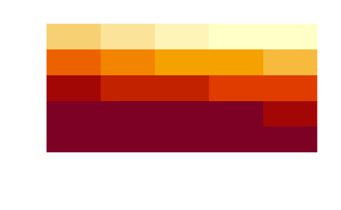

```r
mufilter<-rnorm(lsize^2) # independent random numbers normally distributed for the grid
sigmafilter<-10 # parameter for a Gaussian filter
surface<-gaussianSmooth(mufilter,sigmafilter) # Gaussian filter applied to get correlated values

# Tranforming the numbers for values of the parameter tauin that make sense for the model; for instance, they need to be positive
surface=surface-min(surface)
surface=0.2+2*surface
surface=matrix(surface,lsize,lsize) # the numbers are finally stored in a matrix
image((surface), useRaster=TRUE, axes=FALSE)
```

```r
surface
```

```
          [,1]      [,2]      [,3]      [,4]      [,5]
[1,] 0.4851241 0.4817327 0.4448395 0.3762351 0.2838526
[2,] 0.4869850 0.4770776 0.4334759 0.3593309 0.2634614
[3,] 0.4876186 0.4710524 0.4208710 0.3415519 0.2426350
[4,] 0.4869786 0.4636595 0.4070830 0.3229864 0.2214553
[5,] 0.4850264 0.4549132 0.3921795 0.3037235 0.2000000
```

```r
theta1<-surface[sampled] # training points (values)
theta1
```

```
[1] 0.4851241 0.4850264 0.4636595 0.4208710 0.3593309 0.2838526 0.2000000
```

```r
M1<-length(sampled) # number of training points
M2<-length(notsampled) # number of predicted points
M=M1+M2
```

The synthetic data is generated in Stan. For the differential equation model, the system was solved using an adaptive forward Euler scheme, where a smaller step size was used for upstroke and a little bit after that and a bigger step size for the rest of the AP.

```stan
functions { # The Mitchell-Schaefer model; only the voltage variable is saved
  real[] ms(real[] y0,
            real t0,
            real[] Ts,
            real[] theta,
            real period,
            int N){
    real vsave[N];
    real v = y0[1];
    real h = y0[2];
    real stimmag;
    real p;
    real dt;
    real dt1=0.1;
    real dt2=0.5;

    real auxt;

    for (ntime in 1:N){
      auxt=fmod(Ts[ntime],period);
      if(auxt>=0 && auxt<=4){
        dt=dt1;
        if(auxt>=0 && auxt<=1) # stimulus applied for 1 ms each CL
          stimmag=0.66;
        else
          stimmag=0;
      }
      else{
        dt=dt2;
      }
      p=0.5*(tanh(50*(v-theta[5]))+1);
      h=h + ( (1-h)*(1-p)/theta[3] - h*p/theta[4])*dt;
      v=v + (h*v^2*(1-v)/theta[1]-v/theta[2]+stimmag)*dt;

      vsave[ntime] = v;
    }
    return vsave;
  }
}
data {
  int<lower=1> T; # length of the vector of total time for the given CL (last 2 AP)
  int<lower=1> m; # population size
  real y0[2]; # initial conditions
  real t0; # time at which the initial conditions are given
  real period; # CL for pacing
  real theta[5,m]; # matrix of 5 rows (number of parameters) by m columns
  int N; # length of the vector of total time for all the CLs (6 APs)
  real Ts[N]; # vector of the times for each CL
}
model {
}
generated quantities {
  real y_hat[N];
  real y[T,m];
  for (j in 1:m){
    y_hat = ms(y0, t0, Ts, theta[,j], period, N);
    for (t in 1:T)
      y[t,j] = y_hat[T*2+t]; #just the last 2 APs (out of 6) are taken
  }
  for (j in 1:m){ # Random noise is added to the solution
    for (t in 1:T)
      y[t,j] += normal_rng(0, 0.03);
  }
}
```

[output not shown]

Call from R to generate the synthetic data using Stan

```r
library(rstan)
rstan_options (auto_write = TRUE)
options (mc.cores = parallel::detectCores ())
set.seed(1)

# step sizes for the solution of the ODE system (MS)
dt1<-0.1 # upstroke
dt2<-0.5 # the rest of the AP

periods<-c(350,300,276) # 1 CL for fitting with no alternans; 2 CLs with alternans
nperiods<-length(periods)

# To print the APs faster and separated, not linked
Yaux<-vector("list",nperiods) # 2 AP for each CL fine res
Y<-vector("list",nperiods) # 2 AP for each CL coarse
TS<-vector("list",nperiods) # 2 AP time for each CL
Tode<-vector("list",nperiods) # 6 AP time for each CL
Ts2<-{} # 6 AP time for all CL
ts<-{}
tsnr<-{}
y<-{} # 2 AP for all CL
nts<-rep(0,nperiods) # length of 2 AP for each CL
ntsnr<-rep(0,nperiods)
indexes<-vector("list",nperiods)

# Values taken from the MS paper
thetatrue<-c(0.3,6,150,120,0.13)

# A population of M1 perturbed vectors, based on the true values, is created
# M1 is the number of training points
sdev<-0.1*thetatrue
Theta<-t(mapply(function(x1,x2){rnorm(M1,x1,x2)},x1=thetatrue,x2=sdev))
Theta[1,]<-theta1
Theta
```

```
            [,1]        [,2]        [,3]        [,4]        [,5]        [,6]
[1,]   0.4851241   0.4850264   0.4636595   0.4208710   0.3593309   0.2838526
[2,]   6.4429948   6.3454688   5.8167670   6.9070687   6.2339059   5.6272557
[3,] 166.8739638 149.3259959 149.7571461 164.1575432 162.3183179 158.9085198
[4,] 129.3856356 120.8947798  96.1277796 127.4379090 119.3264551 118.1304539
[5,]   0.1237840   0.1354332   0.1476628   0.1286638   0.1350397   0.1293005
            [,7]
[1,]   0.2000000
[2,]   4.6711801
[3,] 163.7846606
[4,] 102.3509714
[5,]   0.1120982
```

```r
ptm<-proc.time()
for (i in 1:nperiods){
  # resolution to solve the ODE system
  auxts1<-c(seq(dt1,4,by=dt1),seq(4+dt2,periods[i],by=dt2)) # time for first APs
  auxts2<-periods[i]+auxts1 # time for second AP
  auxts<-c(auxts1,auxts2) # time 2 (last) AP

  ts<-c(ts,auxts)
  auxn<-length(auxts)
  nts[i]<-auxn # size of the time vector for each CL
  auxN<-3*auxn # size for 6 AP

  # resolution for fitting
  newres1<-c(seq(0.1,4,by=0.5),seq(5,periods[i],by=10))
  newres2<-periods[i]+newres1 # time for second AP
  newres<-c(newres1,newres2)
  indexes[[i]]<-match(newres,auxts)

  tsnr<-c(tsnr,newres)
  auxnnr<-length(newres)
  ntsnr[i]<-auxnnr
  auxNnr<-3*auxnnr # size for 6 AP

  Ts<-{}
  for (j in seq(0,4,by=2)){
    Ts<-c(Ts,auxts+j*periods[i]) # 6 AP time for one CL
  }
  Tode[[i]]<-Ts
  Ts2<-c(Ts2,Ts)
  MS_data<-list(T = auxn, m=M1, y0 = c(0,1), t0 = 0, period=periods[i],
                theta = Theta,Ts=Ts,N=auxN)
  synpoints <- rstan::sampling(dataforMSGP,
    data = MS_data,    # named list of data
    chains = 1,             # number of Markov chains
    iter = 1,            # total number of iterations per chain
    algorithm = 'Fixed_param',
    seed=0
  )
  Yaux[[i]]<-extract(synpoints, pars = "y")$y[1,,]
  Y[[i]]<-Yaux[[i]][indexes[[i]],]
  TS[[i]]<-newres
}
n<-sum(nts)
NTs<-3*nts
N<-3*n

# new
nnr<-sum(ntsnr)
NTsnr<-3*ntsnr
Nnr<-3*nnr
nr<-{}
for (i in 1:nperiods)
  nr<-c(nr,indexes[[i]])

print(proc.time()-ptm)
```

```
   user  system elapsed
  1.838   0.008   1.832
```

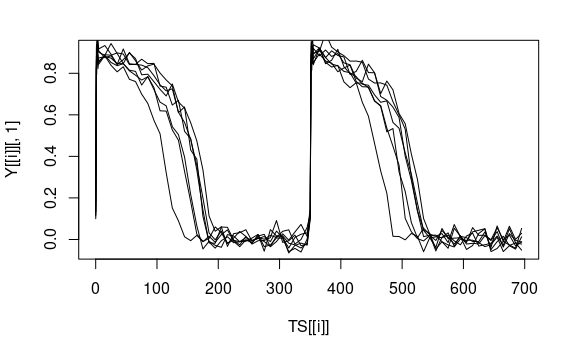

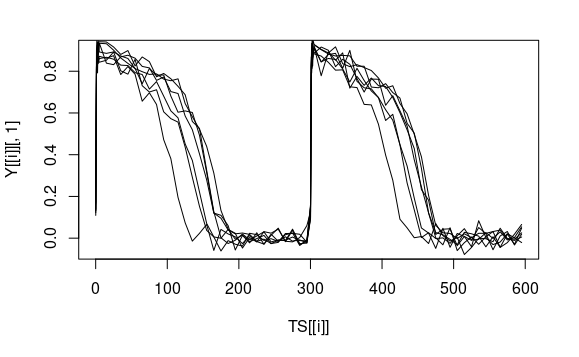

```r
# Link the last two APs for each CL one after the other to do inference
yy<-{}
for (i in 1:nperiods)
  yy<-rbind(yy,Y[[i]])

# Plot the AP profiles separated
for (i in 1:nperiods){
  plot(TS[[i]],Y[[i]][,1],type='l')
  for (j in 2:M1)
    lines(TS[[i]],Y[[i]][,j])
}
```

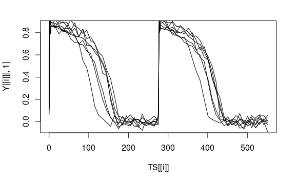

```r
NA
```

Except for $\tau_{in}$, the priors selected for each parameter of the MS model were selected as folded normals (meaning that the samples are taken as just the non-negative support of a normal distribution). The priors have mean equal to the true value and a standard deviation of 20% of the mean.

```stan
functions {
  real[] ms(real[] y0,
            real t0,
            real[] Ts,
            real[] theta,
            real period,
            int N){
    real vsave[N];
    real v = y0[1];
    real h = y0[2];
    real stimmag=0;
    real p;
    real dt;
    real dt1=0.1;
    real dt2=0.5;
    real auxt;

    for (ntime in 1:N){
      auxt=fmod(Ts[ntime],period);
      if(auxt>=0 && auxt<=4){
        dt=dt1;
        if(auxt>=0 && auxt<=1)
          stimmag=0.66;
        else
          stimmag=0;
      }
      else{
        dt=dt2;
      }
      p=0.5*(tanh(50*(v-theta[5]))+1);
      h=h + ( (1-h)*(1-p)/theta[3] - h*p/theta[4])*dt;
      v=v + (h*v^2*(1-v)/theta[1]-v/theta[2]+stimmag)*dt;

      vsave[ntime] = v;
    }
    return vsave;
  }
}
data {
  int<lower=1> nCL; # number of CL used
  int nts[nCL];
  int<lower=1> T; # length of the vector of total time for all the CLs (last 2 AP)
  int<lower=1> M1; # number of data given
  int<lower=1> M2; # number of data to predict
  int<lower=1> M; # M=M1+M2
  real y1[T,M1];
  real y0[2];
  real t0;
  real periods[nCL];
  int N; # length of the vector of total time for all the CLs (6 AP)
  real Ts[N]; # vector of the times for each CL
  int NTs[nCL];
  int nr[T];
  int ntsnr[nCL];
  vector[2] x[M];
  vector[M1] tauin1;
}
transformed data {
  real delta = 1e-9;
}
parameters {
  real<lower=0> sigma[M1]; # noise added to the solution
  real<lower=0> mu[4];
  real<lower=0> theta[4,M1];

  real<lower=0> rho;
  real<lower=0> alpha;
  real<lower=0> sigma_gp;
  vector[M] eta;
}
transformed parameters {
  vector[M] f;
  {
    matrix[M, M] L_K;
    matrix[M, M] K = cov_exp_quad(x, alpha, rho);

    # diagonal elements
    for (m in 1:M)
      K[m, m] = K[m, m] + delta;

    L_K = cholesky_decompose(K);
    f = 0.3+L_K * eta;
  }
}
model {
  real y1_hat[N,M1];
  int aux;
  int aux2;
  real auxtheta[5];
  aux=0;
  for (i in 1:nCL){
    for (j in 1:M1){
      auxtheta[1]=tauin1[j];
      auxtheta[2:5]=theta[,j];
      y1_hat[ (aux+1):(aux+NTs[i]),j] = ms(y0, t0, Ts[(aux+1):(aux+NTs[i])], auxtheta, periods[i], NTs[i]);
    }
    aux=aux+NTs[i];
  }
  for (j in 1:M1){
    aux=0; # for the last 2 AP
    aux2=0;# for the total AP
    for (i in 1:nCL){
      for (t in 1:ntsnr[i])
        y1[aux+t,j] ~ normal(y1_hat[(aux2+2*nts[i]+nr[t+aux]),j], sigma[j]);
      aux=aux+ntsnr[i];
      aux2=aux2+NTs[i];
    }
  }
  sigma ~ normal(0,0.5);
  rho ~ uniform(1,6);
  alpha ~ std_normal();
  sigma_gp ~ std_normal();
  eta ~ std_normal();
  mu[1] ~ normal(6,1.2);
  mu[2] ~ normal(150,30);
  mu[3] ~ normal(120,24);
  mu[4] ~ normal(0.13,0.026);
  tauin1 ~ normal(f[1:M1],sigma_gp);
  theta[1] ~ normal(mu[1],1.2);
  theta[2] ~ normal(mu[2],30);
  theta[3] ~ normal(mu[3],24);
  theta[4] ~ normal(mu[4],0.026);
}
generated quantities {
  vector[M2] tauin2;
  for (m2 in 1:M2)
    tauin2[m2] = normal_rng(f[M1 + m2], sigma_gp);
}
```

[output not shown]

Call from R to perform inference using Stan:

```r
stan_data<-list(nCL = nperiods, nts=nts, T=nnr, M1=M1, M2=M2, M=M, y1=yy, y0 = c(0,1), t0 = 0, periods = periods ,
                N=N ,Ts=Ts2, NTs=NTs, nr=nr, ntsnr=ntsnr, x=x, tauin1=theta1)

ptm<-proc.time()
fit <- rstan::sampling(MS,
  data = stan_data,    # named list of data
  chains = 1,             # number of Markov chains
  warmup = 1000,          # number of warmup iterations per chain
  iter = 1500,            # total number of iterations per chain
  cores = 1,              # number of cores (could use one per chain)
  refresh = 75,             # progress shown
  init=list(list(theta=matrix(rep(c(6,120,150,0.13),M1),4,M1))),
  control=list(adapt_delta = 0.8)
)
print(proc.time()-ptm)
```

```
    user   system  elapsed
9459.235    0.744 9464.010
```

```r
# Table of results
print(fit)
```

```
Inference for Stan model: stan-2711de960d2e.
1 chains, each with iter=1500; warmup=1000; thin=1;
post-warmup draws per chain=500, total post-warmup draws=500.

              mean se_mean    sd    2.5%     25%     50%     75%   97.5% n_eff
sigma[1]      0.03    0.00  0.00    0.02    0.02    0.03    0.03    0.03    99
sigma[2]      0.03    0.00  0.00    0.03    0.03    0.03    0.03    0.03    95
sigma[3]      0.03    0.00  0.00    0.03    0.03    0.03    0.03    0.03   163
sigma[4]      0.03    0.00  0.00    0.03    0.03    0.03    0.03    0.03   158
sigma[5]      0.03    0.00  0.00    0.03    0.03    0.03    0.03    0.04   138
sigma[6]      0.03    0.00  0.00    0.03    0.03    0.03    0.03    0.03   128
sigma[7]      0.03    0.00  0.00    0.03    0.03    0.03    0.03    0.03    77
mu[1]         6.20    0.04  0.43    5.41    5.91    6.20    6.48    7.10   137
mu[2]       162.57    1.17 11.21  143.15  154.47  161.91  170.59  184.91    91
mu[3]       115.59    0.67  7.88   98.25  110.12  115.71  122.08  127.54   140
mu[4]         0.14    0.00  0.02    0.10    0.12    0.14    0.15    0.18    39
theta[1,1]    6.65    0.05  0.34    6.14    6.37    6.61    6.92    7.30    40
theta[1,2]    6.56    0.04  0.29    5.98    6.37    6.52    6.73    7.14    48
theta[1,3]    6.13    0.05  0.33    5.47    5.90    6.12    6.33    6.78    45
theta[1,4]    6.86    0.03  0.30    6.29    6.67    6.85    7.05    7.42    96
theta[1,5]    6.40    0.04  0.34    5.78    6.20    6.37    6.62    7.08    57
theta[1,6]    6.18    0.05  0.34    5.55    5.95    6.15    6.36    6.91    43
theta[1,7]    4.76    0.04  0.26    4.32    4.58    4.72    4.93    5.29    42
theta[2,1]  167.71    1.65 12.24  146.60  158.99  168.01  175.55  192.21    55
theta[2,2]  156.49    1.27 10.88  134.21  148.79  156.61  163.59  177.60    73
theta[2,3]  165.60    1.90 15.82  132.38  154.58  166.25  176.83  193.96    70
theta[2,4]  160.29    1.08  9.68  141.46  153.54  159.64  168.31  177.05    80
theta[2,5]  161.30    1.04 10.11  143.91  154.12  160.57  167.82  183.27    94
theta[2,6]  180.59    1.66 11.19  157.04  173.84  180.01  187.67  202.55    46
theta[2,7]  163.16    1.48 10.02  144.25  154.93  162.52  170.61  181.60    46
theta[3,1]  126.06    0.58  4.04  118.32  122.89  126.67  129.35  132.62    48
theta[3,2]  119.57    0.49  3.48  113.65  117.05  119.88  121.81  126.65    50
theta[3,3]   94.85    0.52  3.40   88.33   92.29   94.87   97.56  100.73    43
theta[3,4]  125.99    0.45  3.75  118.91  123.47  125.76  128.77  133.96    68
theta[3,5]  116.74    0.53  3.83  109.74  114.31  116.61  118.72  124.93    53
theta[3,6]  114.54    0.48  3.36  108.19  112.57  114.72  116.81  120.48    49
theta[3,7]  100.63    0.40  2.89   95.44   98.53  100.86  102.74  105.80    53
theta[4,1]    0.13    0.00  0.03    0.07    0.11    0.13    0.15    0.19    59
theta[4,2]    0.14    0.00  0.03    0.08    0.12    0.14    0.16    0.21    74
theta[4,3]    0.14    0.01  0.04    0.05    0.12    0.14    0.17    0.21    32
```

[output cut: 157 more lines]

```
f[25]      1.02
tauin2[1]  1.00
tauin2[2]  1.00
tauin2[3]  1.00
tauin2[4]  1.02
tauin2[5]  1.01
tauin2[6]  1.00
tauin2[7]  1.00
tauin2[8]  1.02
 [ reached getOption("max.print") -- omitted 11 rows ]

Samples were drawn using NUTS(diag_e) at Mon Oct 18 22:31:15 2021.
For each parameter, n_eff is a crude measure of effective sample size,
and Rhat is the potential scale reduction factor on split chains (at
convergence, Rhat=1).
```

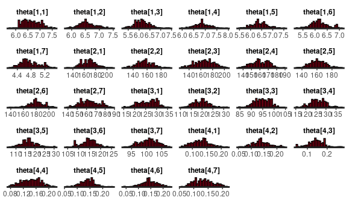

```r
# Histograms of the MS parameters except tau_in
stan_hist(fit,pars='theta')
```

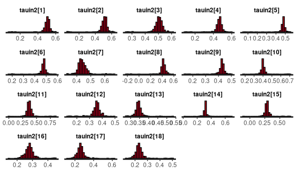

```r
# Histograms of the parameter in space (tau_in) at each predicted location
stan_hist(fit,pars='tauin2')
```

Plotting of the results shown on the slides. The package lattice needs to be installed.

```r
# Table of results
print(fit)
```

```
Inference for Stan model: stan-2711de960d2e.
1 chains, each with iter=1500; warmup=1000; thin=1;
post-warmup draws per chain=500, total post-warmup draws=500.

              mean se_mean    sd    2.5%     25%     50%     75%   97.5% n_eff
sigma[1]      0.03    0.00  0.00    0.02    0.02    0.03    0.03    0.03    99
sigma[2]      0.03    0.00  0.00    0.03    0.03    0.03    0.03    0.03    95
sigma[3]      0.03    0.00  0.00    0.03    0.03    0.03    0.03    0.03   163
sigma[4]      0.03    0.00  0.00    0.03    0.03    0.03    0.03    0.03   158
sigma[5]      0.03    0.00  0.00    0.03    0.03    0.03    0.03    0.04   138
sigma[6]      0.03    0.00  0.00    0.03    0.03    0.03    0.03    0.03   128
sigma[7]      0.03    0.00  0.00    0.03    0.03    0.03    0.03    0.03    77
mu[1]         6.20    0.04  0.43    5.41    5.91    6.20    6.48    7.10   137
mu[2]       162.57    1.17 11.21  143.15  154.47  161.91  170.59  184.91    91
mu[3]       115.59    0.67  7.88   98.25  110.12  115.71  122.08  127.54   140
mu[4]         0.14    0.00  0.02    0.10    0.12    0.14    0.15    0.18    39
theta[1,1]    6.65    0.05  0.34    6.14    6.37    6.61    6.92    7.30    40
theta[1,2]    6.56    0.04  0.29    5.98    6.37    6.52    6.73    7.14    48
theta[1,3]    6.13    0.05  0.33    5.47    5.90    6.12    6.33    6.78    45
theta[1,4]    6.86    0.03  0.30    6.29    6.67    6.85    7.05    7.42    96
theta[1,5]    6.40    0.04  0.34    5.78    6.20    6.37    6.62    7.08    57
theta[1,6]    6.18    0.05  0.34    5.55    5.95    6.15    6.36    6.91    43
theta[1,7]    4.76    0.04  0.26    4.32    4.58    4.72    4.93    5.29    42
theta[2,1]  167.71    1.65 12.24  146.60  158.99  168.01  175.55  192.21    55
theta[2,2]  156.49    1.27 10.88  134.21  148.79  156.61  163.59  177.60    73
theta[2,3]  165.60    1.90 15.82  132.38  154.58  166.25  176.83  193.96    70
theta[2,4]  160.29    1.08  9.68  141.46  153.54  159.64  168.31  177.05    80
theta[2,5]  161.30    1.04 10.11  143.91  154.12  160.57  167.82  183.27    94
theta[2,6]  180.59    1.66 11.19  157.04  173.84  180.01  187.67  202.55    46
theta[2,7]  163.16    1.48 10.02  144.25  154.93  162.52  170.61  181.60    46
theta[3,1]  126.06    0.58  4.04  118.32  122.89  126.67  129.35  132.62    48
theta[3,2]  119.57    0.49  3.48  113.65  117.05  119.88  121.81  126.65    50
theta[3,3]   94.85    0.52  3.40   88.33   92.29   94.87   97.56  100.73    43
theta[3,4]  125.99    0.45  3.75  118.91  123.47  125.76  128.77  133.96    68
theta[3,5]  116.74    0.53  3.83  109.74  114.31  116.61  118.72  124.93    53
theta[3,6]  114.54    0.48  3.36  108.19  112.57  114.72  116.81  120.48    49
theta[3,7]  100.63    0.40  2.89   95.44   98.53  100.86  102.74  105.80    53
theta[4,1]    0.13    0.00  0.03    0.07    0.11    0.13    0.15    0.19    59
theta[4,2]    0.14    0.00  0.03    0.08    0.12    0.14    0.16    0.21    74
theta[4,3]    0.14    0.01  0.04    0.05    0.12    0.14    0.17    0.21    32
```

[output cut: 157 more lines]

```
f[25]      1.02
tauin2[1]  1.00
tauin2[2]  1.00
tauin2[3]  1.00
tauin2[4]  1.02
tauin2[5]  1.01
tauin2[6]  1.00
tauin2[7]  1.00
tauin2[8]  1.02
 [ reached getOption("max.print") -- omitted 11 rows ]

Samples were drawn using NUTS(diag_e) at Mon Oct 18 22:31:15 2021.
For each parameter, n_eff is a crude measure of effective sample size,
and Rhat is the potential scale reduction factor on split chains (at
convergence, Rhat=1).
```

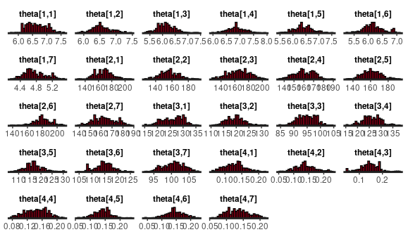

```r
# Histograms of the MS parameters except tau_in
stan_hist(fit,pars='theta')
```

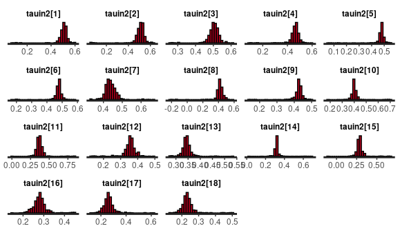

```r
# Histograms of the parameter in space (tau_in) at each predicted location
stan_hist(fit,pars='tauin2')
```

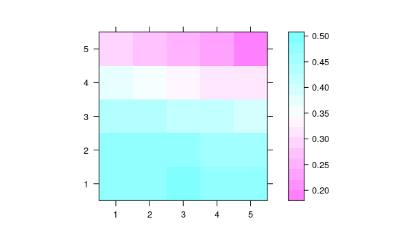

```r
sol<-extract(fit, permuted = TRUE, inc_warmup = FALSE, include = TRUE)

# Posterior means
tauin2<-sol$tauin2
meanstauin2<-{}

# mean
for (i in 1:M2){
  meanstauin2[i]<-mean(tauin2[,i])
}

# variance for the bars of the correlation plot
vartauin2<-rep(0,M2)
for (i in 1:M2){
  vartauin2[i]<-var(tauin2[,i])
}

# Grid construction from the inference done, using predicted and non-predicted values
sdtauin2<-sqrt(vartauin2)
predsurface<-rep(0,M)
j1<-1;
j2<-1;
for (i in 1:M){
  if (i==sampled[j1] && j1<=M1){
    predsurface[i]<-theta1[j1];
    j1<-j1+1;
  }
  else{
    if (i==notsampled[j2] && j2<=M2){
      predsurface[i]<-meanstauin2[j2]
      j2<-j2+1;
    }
  }
}

library(lattice)
# Grid of the true values
levelplot((surface),xlab="",ylab="")
```

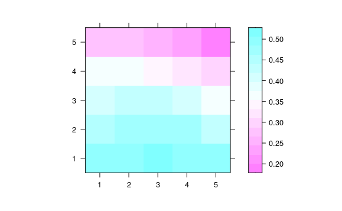

```r
# Grid of the predicted values
postsurface=matrix(predsurface,lsize,lsize)
levelplot((postsurface),xlab="",ylab="")
```

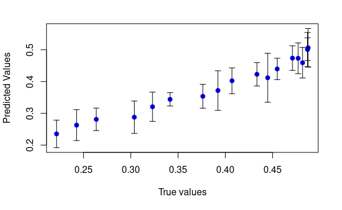

```r
# Pearson correlation coefficient and correlation plot
plot(surface[notsampled],meanstauin2,
     ylim=range(c(meanstauin2-sdtauin2, meanstauin2+sdtauin2)),
     pch=19, col='blue', xlab="True values", ylab="Predicted Values")
arrows(surface[notsampled], meanstauin2-sdtauin2, surface[notsampled], meanstauin2+sdtauin2, length=0.05, angle=90, code=3)
```

```r
cor.test(surface[notsampled],meanstauin2)
```

```
    Pearson's product-moment correlation

data:  surface[notsampled] and meanstauin2
t = 21.505, df = 16, p-value = 3.117e-13
alternative hypothesis: true correlation is not equal to 0
95 percent confidence interval:
 0.9542812 0.9938386
sample estimates:
      cor
0.9831383
```

Call from R to call Stan and print the data at a different resolution from the one in the synthetic data.

```r
# Distribution of of all the parameters at the population level, except for tau_in
mu4par<-sol$mu

# Distributions for all the parameters, included tau_in at the location where the action potentials are going to be calculated

mu11<-cbind(tauin2[,11],mu4par)

# To plot just 50 action potentials from the sample of size 500
muestreo<-sample(seq(1,500),50,replace=F)

pop<-mu11[muestreo,]
mpop=length(muestreo)
Ypop<-vector("list",nperiods)

ptm<-proc.time()
for (i in 1:nperiods){
  MSpop<-list(T = nts[i], m=mpop, y0 = c(0,1), t0 = 0, period=periods[i],
              theta = t(pop),Ts=Tode[[i]],N=NTs[i])
  poppoints <- rstan::sampling(dataforMSGP,
    data = MSpop,    # named list of data
    chains = 1,             # number of Markov chains
    iter = 1,            # total number of iterations per chain
    algorithm = 'Fixed_param',
    seed=0
  )
  Ypop[[i]]<-extract(poppoints, pars = "y")$y[1,,]
}
timepop<-proc.time()-ptm
print(timepop)
```

```
   user  system elapsed
 78.209   0.008  78.215
```

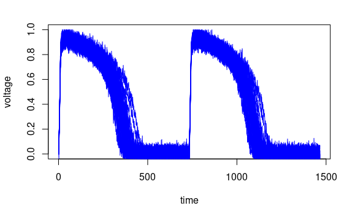

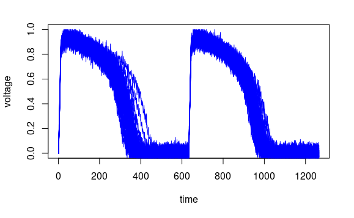

```r
for (i in 1:nperiods){
  Ypop[[i]]<-rbind( Ypop[[i]][nts[i],],Ypop[[i]][1:(nts[i]-1),])
  Ypop[[i]][,1]<-Ypop[[i]][,1]/max(Ypop[[i]][,1])
  plot(c(0,Ypop[[i]][,1]),type='l',col='blue',xlab='time',ylab='voltage',ylim=c(0,1))
  for (j in 2:mpop){
    Ypop[[i]][,j]<-Ypop[[i]][,j]/max(Ypop[[i]][,j])
    lines(c(0,Ypop[[i]][,j]),col = 'blue',xlab='time',ylab='voltage',ylim=c(0,1))
  }
}
```

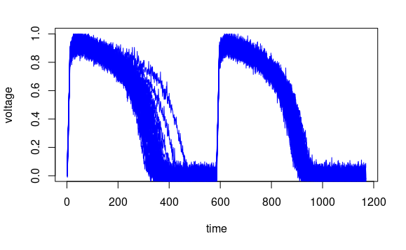

```r
NA
```

I suggest copying the programs separately and run the code using RStudio instead of running this script. I think it is faster.

To not add more code, the population of predicted action potential profiles was generated with noise.

To learn about Gaussian process simulation, fitting and prediction, you could read the Stan Manual sections 10.1-10.3.